# Part I - Exploring riding made in a bike-sharing system

## Introduction

This data set includes information about individual rides made in a bike-sharing system covering the greater San Francisco Bay area.

```python
# import all packages and set plots to be embedded inline
import numpy as np
import pandas as pd
import matplotlib.pyplot as plt
import seaborn as sns

%matplotlib inline
```

> Load in your dataset and describe its properties through the questions below. Try and motivate your exploration goals through this section.

```python
df_original = pd.read_csv('201902-fordgobike-tripdata.csv')
df = df_original.copy() #let's make copy of original data
df.shape #let's check shape of our data set
```

```
(183412, 16)
```

```python
df.columns
```

```
Index(['duration_sec', 'start_time', 'end_time', 'start_station_id',
       'start_station_name', 'start_station_latitude',
       'start_station_longitude', 'end_station_id', 'end_station_name',
       'end_station_latitude', 'end_station_longitude', 'bike_id', 'user_type',
       'member_birth_year', 'member_gender', 'bike_share_for_all_trip'],
      dtype='object')
```

```python
df.head()
```

|  | duration_sec | start_time | end_time | start_station_id | start_station_name | start_station_latitude | start_station_longitude | end_station_id | end_station_name | end_station_latitude | end_station_longitude | bike_id | user_type | member_birth_year | member_gender | bike_share_for_all_trip |
| --- | --- | --- | --- | --- | --- | --- | --- | --- | --- | --- | --- | --- | --- | --- | --- | --- |
| 0 | 52185 | 2019-02-28 17:32:10.1450 | 2019-03-01 08:01:55.9750 | 21.0 | Montgomery St BART Station (Market St at 2nd St) | 37.789625 | -122.400811 | 13.0 | Commercial St at Montgomery St | 37.794231 | -122.402923 | 4902 | Customer | 1984.0 | Male | No |
| 1 | 42521 | 2019-02-28 18:53:21.7890 | 2019-03-01 06:42:03.0560 | 23.0 | The Embarcadero at Steuart St | 37.791464 | -122.391034 | 81.0 | Berry St at 4th St | 37.775880 | -122.393170 | 2535 | Customer | NaN | NaN | No |
| 2 | 61854 | 2019-02-28 12:13:13.2180 | 2019-03-01 05:24:08.1460 | 86.0 | Market St at Dolores St | 37.769305 | -122.426826 | 3.0 | Powell St BART Station (Market St at 4th St) | 37.786375 | -122.404904 | 5905 | Customer | 1972.0 | Male | No |
| 3 | 36490 | 2019-02-28 17:54:26.0100 | 2019-03-01 04:02:36.8420 | 375.0 | Grove St at Masonic Ave | 37.774836 | -122.446546 | 70.0 | Central Ave at Fell St | 37.773311 | -122.444293 | 6638 | Subscriber | 1989.0 | Other | No |
| 4 | 1585 | 2019-02-28 23:54:18.5490 | 2019-03-01 00:20:44.0740 | 7.0 | Frank H Ogawa Plaza | 37.804562 | -122.271738 | 222.0 | 10th Ave at E 15th St | 37.792714 | -122.248780 | 4898 | Subscriber | 1974.0 | Male | Yes |

```python
df.info()
```

```
<class 'pandas.core.frame.DataFrame'>
RangeIndex: 183412 entries, 0 to 183411
Data columns (total 16 columns):
 #   Column                   Non-Null Count   Dtype
---  ------                   --------------   -----
 0   duration_sec             183412 non-null  int64
 1   start_time               183412 non-null  object
 2   end_time                 183412 non-null  object
 3   start_station_id         183215 non-null  float64
 4   start_station_name       183215 non-null  object
 5   start_station_latitude   183412 non-null  float64
 6   start_station_longitude  183412 non-null  float64
 7   end_station_id           183215 non-null  float64
 8   end_station_name         183215 non-null  object
 9   end_station_latitude     183412 non-null  float64
 10  end_station_longitude    183412 non-null  float64
 11  bike_id                  183412 non-null  int64
 12  user_type                183412 non-null  object
 13  member_birth_year        175147 non-null  float64
 14  member_gender            175147 non-null  object
 15  bike_share_for_all_trip  183412 non-null  object
dtypes: float64(7), int64(2), object(7)
memory usage: 22.4+ MB
```

```python
df.isnull().sum()
```

```
duration_sec                  0
start_time                    0
end_time                      0
start_station_id            197
start_station_name          197
start_station_latitude        0
start_station_longitude       0
end_station_id              197
end_station_name            197
end_station_latitude          0
end_station_longitude         0
bike_id                       0
user_type                     0
member_birth_year          8265
member_gender              8265
bike_share_for_all_trip       0
dtype: int64
```

```python
df.describe()
```

|  | duration_sec | start_station_id | start_station_latitude | start_station_longitude | end_station_id | end_station_latitude | end_station_longitude | bike_id | member_birth_year |
| --- | --- | --- | --- | --- | --- | --- | --- | --- | --- |
| count | 183412.000000 | 183215.000000 | 183412.000000 | 183412.000000 | 183215.000000 | 183412.000000 | 183412.000000 | 183412.000000 | 175147.000000 |
| mean | 726.078435 | 138.590427 | 37.771223 | -122.352664 | 136.249123 | 37.771427 | -122.352250 | 4472.906375 | 1984.806437 |
| std | 1794.389780 | 111.778864 | 0.099581 | 0.117097 | 111.515131 | 0.099490 | 0.116673 | 1664.383394 | 10.116689 |
| min | 61.000000 | 3.000000 | 37.317298 | -122.453704 | 3.000000 | 37.317298 | -122.453704 | 11.000000 | 1878.000000 |
| 25% | 325.000000 | 47.000000 | 37.770083 | -122.412408 | 44.000000 | 37.770407 | -122.411726 | 3777.000000 | 1980.000000 |
| 50% | 514.000000 | 104.000000 | 37.780760 | -122.398285 | 100.000000 | 37.781010 | -122.398279 | 4958.000000 | 1987.000000 |
| 75% | 796.000000 | 239.000000 | 37.797280 | -122.286533 | 235.000000 | 37.797320 | -122.288045 | 5502.000000 | 1992.000000 |
| max | 85444.000000 | 398.000000 | 37.880222 | -121.874119 | 398.000000 | 37.880222 | -121.874119 | 6645.000000 | 2001.000000 |

Let's transform data to make it easier to work with it. Start and end time should be transformed to datetime objects, also I should add columns with a day of week

```python
df['start_time'] = pd.to_datetime(df['start_time'])
df['start_day'] = df.start_time.dt.day_name()
df['start_date'] = df.start_time.dt.date
df['end_date'] = df.start_time.dt.date
df['end_time'] = pd.to_datetime(df['end_time'])
df['end_day'] = df.end_time.dt.day_name()
df.end_day = df.end_day.astype('category')
df.start_day = df.start_day.astype('category')
```

```python
df.info()
```

```
<class 'pandas.core.frame.DataFrame'>
RangeIndex: 183412 entries, 0 to 183411
Data columns (total 20 columns):
 #   Column                   Non-Null Count   Dtype
---  ------                   --------------   -----
 0   duration_sec             183412 non-null  int64
 1   start_time               183412 non-null  datetime64[ns]
 2   end_time                 183412 non-null  datetime64[ns]
 3   start_station_id         183215 non-null  float64
 4   start_station_name       183215 non-null  object
 5   start_station_latitude   183412 non-null  float64
 6   start_station_longitude  183412 non-null  float64
 7   end_station_id           183215 non-null  float64
 8   end_station_name         183215 non-null  object
 9   end_station_latitude     183412 non-null  float64
 10  end_station_longitude    183412 non-null  float64
 11  bike_id                  183412 non-null  int64
 12  user_type                183412 non-null  object
 13  member_birth_year        175147 non-null  float64
 14  member_gender            175147 non-null  object
 15  bike_share_for_all_trip  183412 non-null  object
 16  start_day                183412 non-null  category
 17  start_date               183412 non-null  object
 18  end_date                 183412 non-null  object
 19  end_day                  183412 non-null  category
dtypes: category(2), datetime64[ns](2), float64(7), int64(2), object(7)
memory usage: 25.5+ MB
```

```python
df[df.start_station_id.isnull()]
```

|  | duration_sec | start_time | end_time | start_station_id | start_station_name | start_station_latitude | start_station_longitude | end_station_id | end_station_name | end_station_latitude | end_station_longitude | bike_id | user_type | member_birth_year | member_gender | bike_share_for_all_trip | start_day | start_date | end_date | end_day |
| --- | --- | --- | --- | --- | --- | --- | --- | --- | --- | --- | --- | --- | --- | --- | --- | --- | --- | --- | --- | --- |
| 475 | 1709 | 2019-02-28 20:55:53.932 | 2019-02-28 21:24:23.738 | NaN | NaN | 37.40 | -121.94 | NaN | NaN | 37.40 | -121.93 | 4211 | Customer | 1991.0 | Female | No | Thursday | 2019-02-28 | 2019-02-28 | Thursday |
| 1733 | 1272 | 2019-02-28 18:32:34.273 | 2019-02-28 18:53:46.727 | NaN | NaN | 37.40 | -121.94 | NaN | NaN | 37.41 | -121.96 | 4174 | Subscriber | 1980.0 | Male | No | Thursday | 2019-02-28 | 2019-02-28 | Thursday |
| 3625 | 142 | 2019-02-28 17:10:46.529 | 2019-02-28 17:13:09.431 | NaN | NaN | 37.41 | -121.95 | NaN | NaN | 37.41 | -121.96 | 4283 | Subscriber | 1988.0 | Male | No | Thursday | 2019-02-28 | 2019-02-28 | Thursday |
| 4070 | 585 | 2019-02-28 16:28:45.934 | 2019-02-28 16:38:31.332 | NaN | NaN | 37.39 | -121.93 | NaN | NaN | 37.40 | -121.92 | 4089 | Subscriber | 1984.0 | Male | Yes | Thursday | 2019-02-28 | 2019-02-28 | Thursday |
| 5654 | 509 | 2019-02-28 12:30:17.131 | 2019-02-28 12:38:46.329 | NaN | NaN | 37.40 | -121.92 | NaN | NaN | 37.39 | -121.93 | 4089 | Subscriber | 1984.0 | Male | Yes | Thursday | 2019-02-28 | 2019-02-28 | Thursday |
| ... | ... | ... | ... | ... | ... | ... | ... | ... | ... | ... | ... | ... | ... | ... | ... | ... | ... | ... | ... | ... |
| 176154 | 1447 | 2019-02-02 12:03:04.544 | 2019-02-02 12:27:12.267 | NaN | NaN | 37.40 | -121.93 | NaN | NaN | 37.40 | -121.93 | 4249 | Customer | 1984.0 | Male | No | Saturday | 2019-02-02 | 2019-02-02 | Saturday |
| 179730 | 309 | 2019-02-01 12:59:45.969 | 2019-02-01 13:04:55.426 | NaN | NaN | 37.40 | -121.94 | NaN | NaN | 37.40 | -121.93 | 4249 | Customer | 1987.0 | Female | No | Friday | 2019-02-01 | 2019-02-01 | Friday |
| 179970 | 659 | 2019-02-01 12:17:37.675 | 2019-02-01 12:28:37.014 | NaN | NaN | 37.41 | -121.96 | NaN | NaN | 37.41 | -121.94 | 4092 | Subscriber | 1999.0 | Female | No | Friday | 2019-02-01 | 2019-02-01 | Friday |
| 180106 | 2013 | 2019-02-01 11:33:55.147 | 2019-02-01 12:07:28.940 | NaN | NaN | 37.40 | -121.94 | NaN | NaN | 37.40 | -121.94 | 4251 | Customer | 1990.0 | Female | No | Friday | 2019-02-01 | 2019-02-01 | Friday |
| 181201 | 312 | 2019-02-01 09:26:34.803 | 2019-02-01 09:31:46.921 | NaN | NaN | 37.40 | -121.93 | NaN | NaN | 37.40 | -121.93 | 4208 | Subscriber | 1987.0 | Male | No | Friday | 2019-02-01 | 2019-02-01 | Friday |

197 rows × 20 columns

Let's check what we should do with NaN values in start and end station Id.

```python
for each in df.columns:
    print(each, df[each].nunique())
```

```
duration_sec 4752
start_time 183401
end_time 183397
start_station_id 329
start_station_name 329
start_station_latitude 334
start_station_longitude 335
end_station_id 329
end_station_name 329
end_station_latitude 335
end_station_longitude 335
bike_id 4646
user_type 2
member_birth_year 75
member_gender 3
bike_share_for_all_trip 2
start_day 7
start_date 28
end_date 28
end_day 7
```

Maybe we could use start and end station longitude instead of id?

```python
[long for long in df.start_station_longitude.unique() if df[df.start_station_longitude == long]['start_station_id'].nunique()>1]
```

```
[]
```

```python
[long for long in df.end_station_longitude.unique() if df[df.end_station_latitude == long]['end_station_id'].nunique()>1]
```

```
[]
```

```python
list1 = list(df.end_station_id.value_counts().index)
```

```python
list1.sort()
```

Answer - yes, we could use longitude of station instead of id in this data set.

### What is the structure of your dataset?

The original dataset has 183412 rows and 16 columns, with information about the duration of renting a bike (in a sec), start and end time of renting, start and end station/location name/id, bike id, and user information.

### What is/are the main feature(s) of interest in your dataset?

In first look most interesting features are: start/end time and location, bike id, user type

### What features in the dataset do you think will help support your investigation into your feature(s) of interest?

All features was listed in previous paragraph

## Univariate Exploration

> In this section, investigate distributions of individual variables. If you see unusual points or outliers, take a deeper look to clean things up and prepare yourself to look at relationships between variables.

> **Rubric Tip**: The project (Parts I alone) should have at least 15 visualizations distributed over univariate, bivariate, and multivariate plots to explore many relationships in the data set. Use reasoning to justify the flow of the exploration.

> **Rubric Tip**: Use the "Question-Visualization-Observations" framework throughout the exploration. This framework involves **asking a question from the data, creating a visualization to find answers, and then recording observations after each visualisation.**

Lets make a brief look at distribution of our variables.

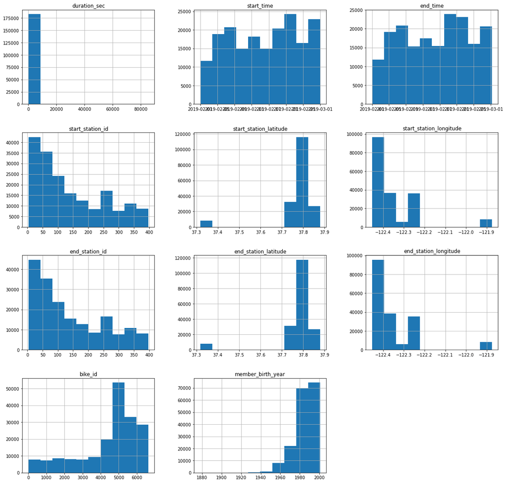

```python
df.hist(figsize=(20,20));
```

```python
df.start_station_id.value_counts()
```

```
58.0     3904
67.0     3544
81.0     3052
21.0     2895
3.0      2760
         ...
301.0       9
51.0        7
300.0       4
224.0       4
344.0       2
Name: start_station_id, Length: 329, dtype: int64
```

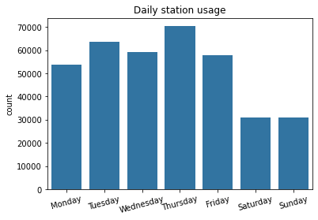

```python
color = sns.color_palette()[0]
order = ['Monday',  'Tuesday', 'Wednesday', 'Thursday', 'Friday', 'Saturday', 'Sunday']
sns.countplot(x= df.start_day.append(df.end_day), order = order,color = color);
plt.xticks(rotation = 15);
plt.title('Daily station usage');
```

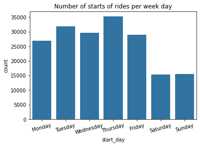

```python
sns.countplot(data = df, x= 'start_day', order = order,color = color);
plt.xticks(rotation = 15);
plt.title('Number of starts of rides per week day');
```

Interesting observation's: we have big outliers in 'duration_sec' variable, member_birth_year. Also interesting observation that most part of bikes was rented in area that stays in latitude 37.7 - 37.9, and longitude -122.4 - -122.2. This information need further inspection. For me was unexpected that most bike's was rented in weekday's, not in weekend's.

Let's look deeper at variables with outliers

```python
df.describe()
```

|  | duration_sec | start_station_id | start_station_latitude | start_station_longitude | end_station_id | end_station_latitude | end_station_longitude | bike_id | member_birth_year |
| --- | --- | --- | --- | --- | --- | --- | --- | --- | --- |
| count | 183412.000000 | 183215.000000 | 183412.000000 | 183412.000000 | 183215.000000 | 183412.000000 | 183412.000000 | 183412.000000 | 175147.000000 |
| mean | 726.078435 | 138.590427 | 37.771223 | -122.352664 | 136.249123 | 37.771427 | -122.352250 | 4472.906375 | 1984.806437 |
| std | 1794.389780 | 111.778864 | 0.099581 | 0.117097 | 111.515131 | 0.099490 | 0.116673 | 1664.383394 | 10.116689 |
| min | 61.000000 | 3.000000 | 37.317298 | -122.453704 | 3.000000 | 37.317298 | -122.453704 | 11.000000 | 1878.000000 |
| 25% | 325.000000 | 47.000000 | 37.770083 | -122.412408 | 44.000000 | 37.770407 | -122.411726 | 3777.000000 | 1980.000000 |
| 50% | 514.000000 | 104.000000 | 37.780760 | -122.398285 | 100.000000 | 37.781010 | -122.398279 | 4958.000000 | 1987.000000 |
| 75% | 796.000000 | 239.000000 | 37.797280 | -122.286533 | 235.000000 | 37.797320 | -122.288045 | 5502.000000 | 1992.000000 |
| max | 85444.000000 | 398.000000 | 37.880222 | -121.874119 | 398.000000 | 37.880222 | -121.874119 | 6645.000000 | 2001.000000 |

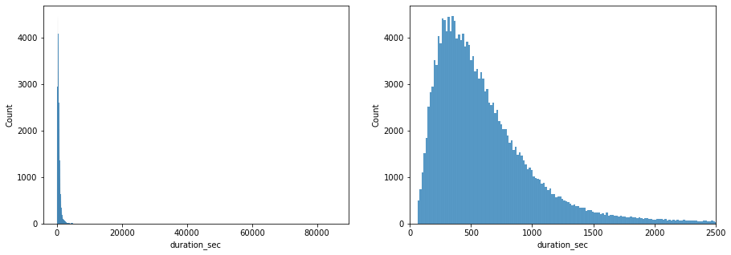

```python
plt.figure(figsize=(15,5))

plt.subplot(1,2,1)
sns.histplot(data = df,x='duration_sec',color = color);

plt.subplot(1,2,2)
sns.histplot(data = df,x='duration_sec',color = color);
plt.xlim(0,2500);
```

In cause that we have long tale let's make log transform

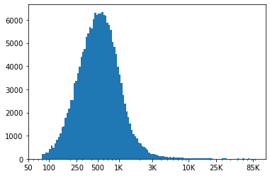

```python
bins = 10** np.arange(1.9,np.log10(df.duration_sec).max() +0.025,0.025)
plt.hist(data = df,x='duration_sec', bins = bins);
plt.xscale('log');
ticks = [50,100,250,500,1000,3000,10000,25000,85000]
labels = [str(x) if x<1000 else '{0:.0f}K'.format(x/1000) for x in ticks]
plt.xticks(ticks,labels);
```

When plotted on a log scale, the time of ride looks roughly normal, with a long tail on the right side.

Let's look deeper in birth year of our subscribers

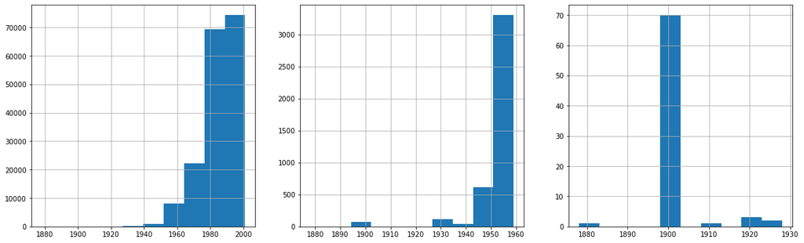

```python
plt.figure(figsize=(20,6))
plt.subplot(1,3,1)
df.member_birth_year.hist()

plt.subplot(1,3,2)
df[df.member_birth_year <1960].member_birth_year.hist();

plt.subplot(1,3,3)
df[df.member_birth_year <1930].member_birth_year.hist();
```

I think there are errors in the dates of birth before 1930, but I'm not entirely sure about the years in the range from 1920 to 1930 (maybe there are some strong old people riding bicycles, or maybe their children use parent's accounts). But I am absolutely sure that the records with the years of birth in the range from 1880 to 1920 were not created correctly. Let's replace incorrect years of birth with NaN values

```python
df.loc[df['member_birth_year'] <1921,['member_birth_year']] = np.NaN
```

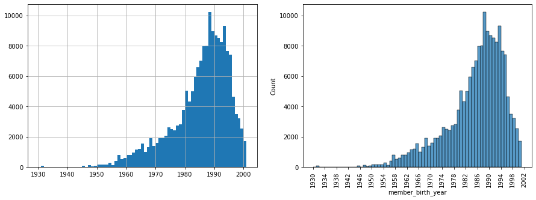

```python
plt.figure(figsize=(15,5))
plt.subplot(1,2,1)
df.member_birth_year.hist(bins = range(1930,2002))

plt.subplot(1,2,2)
sns.histplot(data = df, x = 'member_birth_year',bins = range(1930,2002));
plt.xticks(np.arange(1930,2005,4),rotation = 90);
```

```python
df.member_birth_year.describe()
```

```
count    175072.000000
mean       1984.842333
std           9.968551
min        1927.000000
25%        1980.000000
50%        1987.000000
75%        1992.000000
max        2001.000000
Name: member_birth_year, dtype: float64
```

As we see in plot, most of our subscribers are born around 1984-1994 years

Let's make deeper look at location where bike was rented:

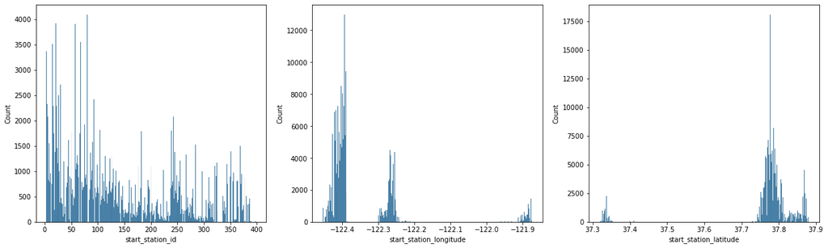

```python
plt.figure(figsize=(21,6))
plt.subplot(1,3,1)
sns.histplot(data = df, x = 'start_station_id',bins = df.start_station_id.nunique());

plt.subplot(1,3,2)
sns.histplot(data = df, x = 'start_station_longitude', bins = df.start_station_longitude.nunique());

plt.subplot(1,3,3)
sns.histplot(data = df, x = 'start_station_latitude', bins = df.start_station_latitude.nunique());
```

```python
b = df[df.start_station_longitude < -122.2]['start_station_id'].nunique() #how much stations we have in longitude lower then -122.2
c = df['start_station_id'].nunique() #how much station we have at all
print ('We have {} station that longitude lower then -122.2, there {} station at all. So {}% of stations stays in this area'.format(b,c,"{0:.1f}".format(b/c*100)))
```

```
We have 283 station that longitude lower then -122.2, there 329 station at all. So 86.0% of stations stays in this area
```

```python
df.start_station_longitude.describe()
```

```
count    183412.000000
mean       -122.352664
std           0.117097
min        -122.453704
25%        -122.412408
50%        -122.398285
75%        -122.286533
max        -121.874119
Name: start_station_longitude, dtype: float64
```

I think we have same distribution in end station's but let's check for sure

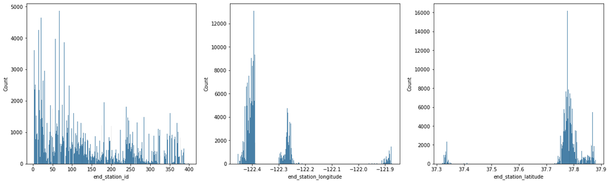

```python
plt.figure(figsize=(21,6))
plt.subplot(1,3,1)
sns.histplot(data = df, x = 'end_station_id', bins = df.end_station_id.nunique());

plt.subplot(1,3,2)
sns.histplot(data = df, x = 'end_station_longitude', bins = df.end_station_longitude.nunique());

plt.subplot(1,3,3)
sns.histplot(data = df, x = 'end_station_latitude', bins = df.end_station_latitude.nunique());
```

So as I expected station's are grouped in same areas. Let's make new station's id in dependence of their longitude.

```python
list_end_stations = list(df.end_station_longitude.unique())
list_end_stations.sort()
list_start_stations = list(df.start_station_longitude.unique())
list_start_stations.sort()
```

```python
len(list_start_stations), len(list_end_stations), list_start_stations == list_end_stations
```

```
(335, 335, True)
```

Everything works like i expected. So let's rework id using station longitude. By doing this work we also remove Nan data in station id.

```python
df['start_station_id_by_long'] = df.start_station_longitude.apply(lambda x: list_start_stations.index(x)+1)
df['end_station_id_by_long'] = df.end_station_longitude.apply(lambda x: list_start_stations.index(x)+1)
```

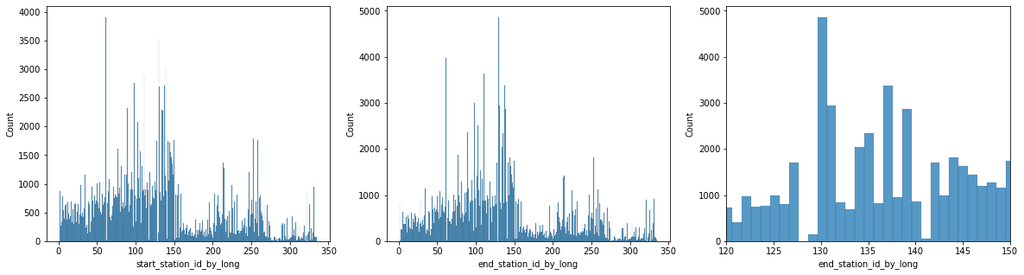

```python
plt.figure(figsize=(20,5))
plt.subplot(1,3,1)
sns.histplot(df.start_station_id_by_long, bins = df.start_station_id_by_long.nunique());

plt.subplot(1,3,2)
sns.histplot(df.end_station_id_by_long, bins = df.end_station_id_by_long.nunique());

plt.subplot(1,3,3)
sns.histplot(df.end_station_id_by_long, bins = df.end_station_id_by_long.nunique());
plt.xlim(120,150);
```

Interesting thing here, a lot of rides end in stations 130-140.

Let's look at distribution ob rides between months. Also let's check is all rides done in one year or not.

```python
df['start_month'] =  df.start_time.dt.month
df['end_month'] = df.end_time.dt.month
df.start_month = df.start_month.astype('category')
df.end_month = df.end_month.astype('category')
df.start_month.value_counts(), df.end_month.value_counts()
```

```
(2    183412
 Name: start_month, dtype: int64,
 2    183396
 3        16
 Name: end_month, dtype: int64)
```

```python
df.start_time.dt.year.value_counts()
```

```
2019    183412
Name: start_time, dtype: int64
```

Thus, all trips started in February 2019 and ended this month as well, with the exception of 16 trips that started in February 2019 and ended in March 2019.

Let's look on distribution of ride's made in every week and day.

```python
df['start_week_num'] = df.start_time.dt.isocalendar().week
df['end_week_num'] = df.end_time.dt.isocalendar().week
```

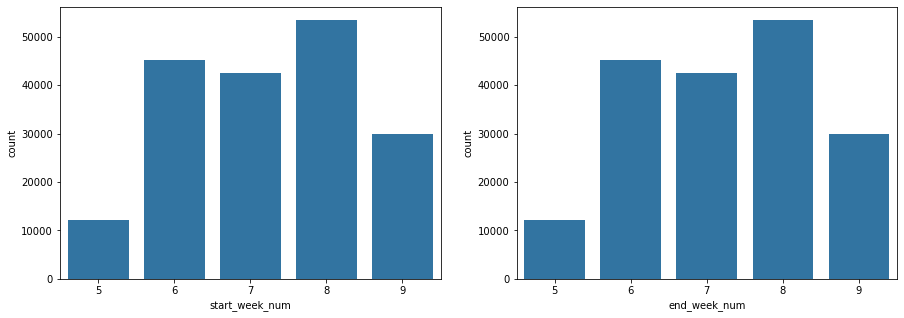

```python
plt.figure(figsize=(15,5))

plt.subplot(1,2,1)
sns.countplot(data = df, x = 'start_week_num',color = color);

plt.subplot(1,2,2)
sns.countplot(data = df, x = 'end_week_num',color = color);
```

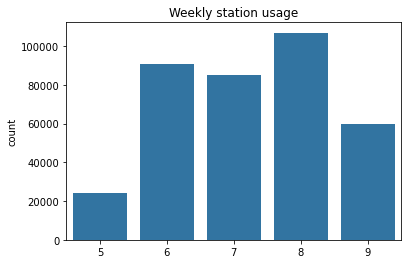

```python
sns.countplot(x = df.start_week_num.append(df.end_week_num),color = color);
plt.title('Weekly station usage');
```

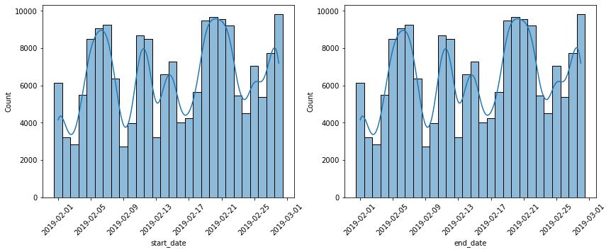

```python
plt.figure(figsize=(14,5))
plt.subplot(1,2,1)
sns.histplot(data = df, x = 'start_date', kde=True);
plt.xticks(rotation = 45);

plt.subplot(1,2,2)
sns.histplot(data = df, x = 'end_date', kde=True);
plt.xticks(rotation = 45);
```

```python
df.groupby(['start_week_num'])['start_date'].nunique()
```

```
start_week_num
5    3
6    7
7    7
8    7
9    4
Name: start_date, dtype: int64
```

```python
df.groupby(['end_week_num'])['end_date'].nunique()
```

```
end_week_num
5    3
6    8
7    8
8    8
9    5
Name: end_date, dtype: int64
```

```python
df.groupby(['start_week_num'])['start_date'].count()
```

```
start_week_num
5    12205
6    45314
7    42460
8    53469
9    29964
Name: start_date, dtype: int64
```

Looking at the charts above, let's not forget that our data only provides complete information about 3 weeks (week number 6,7,8), and weeks num 5,9 are represented by only a few days. Thus, its need further exploration. It will be done in next section.

Let's see if some bikes are used more often than others?

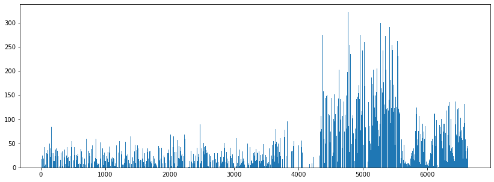

```python
plt.figure(figsize=(14,5))
plt.hist(df.bike_id, bins = df.bike_id.nunique());
```

Let's also check how muck subscribers in our data

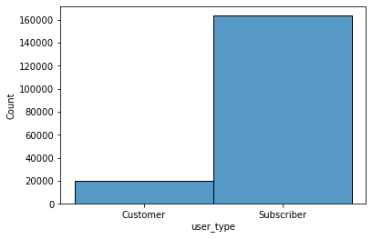

```python
sns.histplot(df.user_type);
```

```python
df['user_type'].value_counts(normalize=True)
```

```
Subscriber    0.891676
Customer      0.108324
Name: user_type, dtype: float64
```

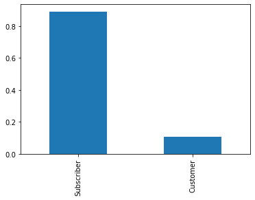

```python
df['user_type'].value_counts(normalize=True).plot(kind = 'bar');
```

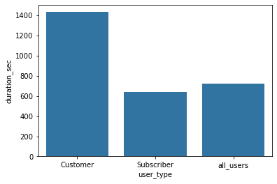

```python
avg = df.groupby(['user_type'])['duration_sec'].mean()
avg['all_users'] = df['duration_sec'].mean()
sns.barplot(x = avg.index, y = avg,color=color);
```

```python
avg
```

```
user_type
Customer      1432.465019
Subscriber     640.263678
all_users      726.078435
Name: duration_sec, dtype: float64
```

Average trip duration of all users are 726 seconds, average trip of subscriber are 640 seconds, and for customer in average time is 1432 seconds.

### Summary for first part

While we look at uni-variate visualization we find some interesting information like: we have big outliers in 'duration_sec' variable, member_birth_year. Also interesting observation that most part of bikes was rented in area that stays in latitude 37.7 - 37.9, and longitude -122.4 - -122.2. This information need further inspection.

After deeper look at date of birth of subscribers I found next information: I think there are errors in the dates of birth before 1930, but I'm not entirely sure about the years in the range from 1920 to 1930 (maybe there are some strong old people riding bicycles, or maybe their children use parent's accounts). But I am absolutely sure that the records with the years of birth in the range from 1878 to 1920 were not created correctly. I decide to remove those

All trips were started in February 2019. 16 trips started in February and were completed in March 2019. Most rides were done at week number 8. In our data, we have complete information about 3 weeks (week number 6,7,8), weeks 5 and 9 represented partly.

Almost 90% of rides was done by subscribers (exact value = 89,17%) Interesting thing here: average duration for subscriber trip is 640 second, and for Customer: 1432 seconds. Average duration of trip at all is 726 seconds.

## Bivariate Exploration

```python
df.info()
```

```
<class 'pandas.core.frame.DataFrame'>
RangeIndex: 183412 entries, 0 to 183411
Data columns (total 26 columns):
 #   Column                    Non-Null Count   Dtype
---  ------                    --------------   -----
 0   duration_sec              183412 non-null  int64
 1   start_time                183412 non-null  datetime64[ns]
 2   end_time                  183412 non-null  datetime64[ns]
 3   start_station_id          183215 non-null  float64
 4   start_station_name        183215 non-null  object
 5   start_station_latitude    183412 non-null  float64
 6   start_station_longitude   183412 non-null  float64
 7   end_station_id            183215 non-null  float64
 8   end_station_name          183215 non-null  object
 9   end_station_latitude      183412 non-null  float64
```

[output cut: 18 more lines]

Let's check the dependence of the number of bike rides and the time of their use.

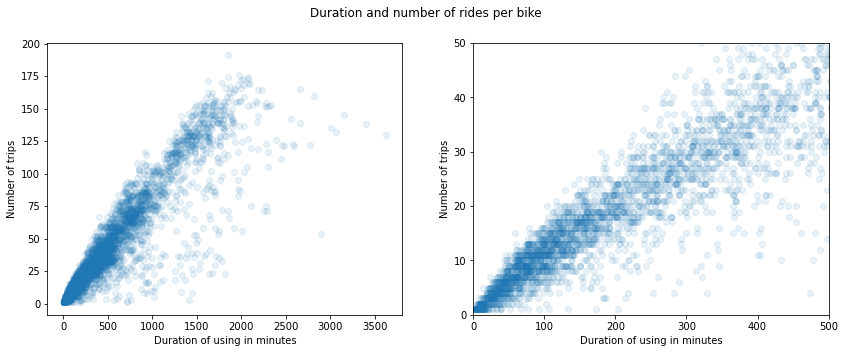

```python
plt.figure(figsize=(14,5))
plt.subplot(1,2,1)
plt.scatter(df.groupby(['bike_id'])['duration_sec'].sum()/60,df.groupby(['bike_id'])['duration_sec'].count(),alpha = 0.1);
plt.ylabel('Number of trips');
plt.xlabel('Duration of using in minutes');

plt.subplot(1,2,2)
plt.scatter(df.groupby(['bike_id'])['duration_sec'].sum()/60,df.groupby(['bike_id'])['duration_sec'].count(),alpha = 0.1);
plt.ylabel('Number of trips');
plt.xlabel('Duration of using in minutes');
plt.xlim(0,500);
plt.ylim(0,50);

plt.suptitle('Duration and number of rides per bike');
```

In the graph above, we can see a clear relationship between the number of trips and the time of use per bike.

Let's make more close look at average trips in every day

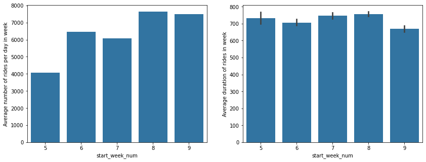

```python
rides_per_weeek = df.groupby(['start_week_num'])['start_date'].count()/df.groupby(['start_week_num'])['start_date'].nunique()

plt.figure(figsize=(14,5))
plt.subplot(1,2,1)
sns.barplot(x=rides_per_weeek.index, y = rides_per_weeek,color = color);
plt.ylabel('Average number of rides per day in week')

plt.subplot(1,2,2)
sns.barplot(data = df, x = 'start_week_num', y = 'duration_sec',color = color);
plt.ylabel('Average duration of rides in week');
```

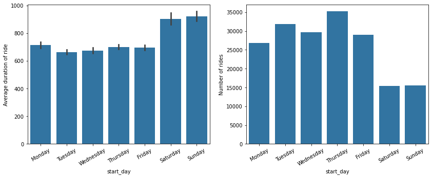

```python
rides_per_day = df.groupby(['start_day'])['start_date'].count()/df.groupby(['start_week_num'])['start_date'].nunique()
plt.figure(figsize=(14,5))
plt.subplot(1,2,1)
sns.barplot(data = df, x = 'start_day',y='duration_sec',color=color, order = order);
plt.xticks(rotation = 30);
plt.ylabel('Average duration of ride')

#for more clear picture lets add one more subplot

plt.subplot(1,2,2)

sns.countplot(data = df,x='start_day', order = order,color = color);
plt.xticks(rotation = 30);
plt.ylabel('Number of rides');
```

As I assumed, the average trip duration on weekends is higher than on weekdays.

```python
df.groupby(['start_day'])['start_date'].nunique()
```

```
start_day
Friday       4
Monday       4
Saturday     4
Sunday       4
Thursday     4
Tuesday      4
Wednesday    4
Name: start_date, dtype: int64
```

So every day of week has the same representation in our data.

## Multivariate Exploration

Let's check how the average trip duration is distributed between the days of the week and the types of users.

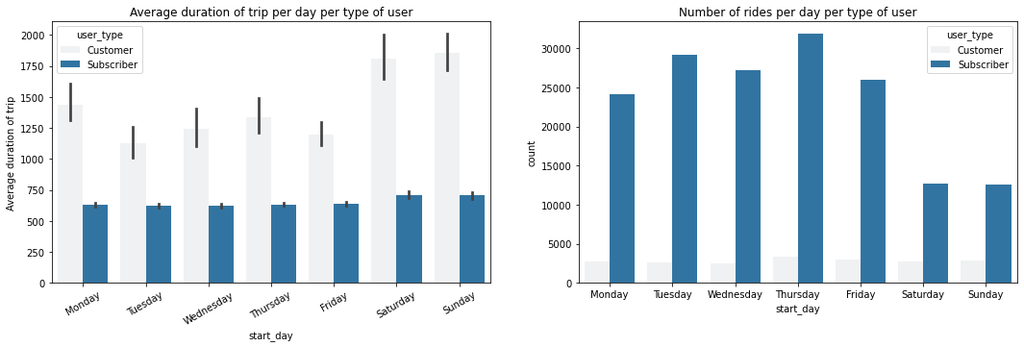

```python
plt.figure(figsize=(18,5))
plt.subplot(1,2,1)
sns.barplot(data = df, x = 'start_day', y = 'duration_sec',hue = 'user_type', order = order,color=color);
plt.xticks(rotation = 30);
plt.ylabel('Average duration of trip');
plt.title('Average duration of trip per day per type of user')

plt.subplot(1,2,2)
sns.countplot(data = df, x = 'start_day', hue = 'user_type',color = color, order = order);
plt.title('Number of rides per day per type of user');
```

So, average duration of trip per day per subscribers are almost identical, but our customers without subscription are really prefer to have long journeys in weekends and on Mondays.

Let's check how many trips were started and ended at the busiest and least busy stations every day.

```python
df_start_station = df.groupby(['start_date','start_station_name'])['duration_sec'].count().reset_index() #let's count how much starts from each station was done in each day
df_start_station.rename(columns = {'duration_sec':'number_of_starts','start_station_name':'station_name','start_date':'date'},inplace = True) #rename columns to merge them in one data frame in future

df_end_station = df.groupby(['end_date','end_station_name'])['duration_sec'].count().reset_index() #same for finishes
df_end_station.rename(columns = {'duration_sec':'number_of_finishes','end_station_name':'station_name','end_date':'date'},inplace = True)

stations_usage = pd.merge(df_start_station,df_end_station,how='outer',left_on=['date','station_name'],right_on=['date','station_name'])
stations_usage[['number_of_starts','number_of_finishes']] = stations_usage[['number_of_starts','number_of_finishes']].fillna(0)
stations_usage.date = pd.to_datetime(stations_usage.date)
stations_usage['day'] = stations_usage.date.dt.day_name()
stations_usage['day_load'] = stations_usage['number_of_starts'] + stations_usage['number_of_finishes']
stations_usage[['number_of_starts','number_of_finishes','day_load']] = stations_usage[['number_of_starts','number_of_finishes','day_load']].astype('int')
stations_usage.day = stations_usage.day.astype('category')
```

```python
stations_usage.info()
```

```
<class 'pandas.core.frame.DataFrame'>
Int64Index: 8829 entries, 0 to 8828
Data columns (total 6 columns):
 #   Column              Non-Null Count  Dtype
---  ------              --------------  -----
 0   date                8829 non-null   datetime64[ns]
 1   station_name        8829 non-null   object
 2   number_of_starts    8829 non-null   int32
 3   number_of_finishes  8829 non-null   int32
 4   day                 8829 non-null   category
 5   day_load            8829 non-null   int32
dtypes: category(1), datetime64[ns](1), int32(3), object(1)
memory usage: 319.4+ KB
```

```python
low_usage = list(stations_usage.groupby(['station_name'])['day_load'].sum().sort_values().index[:7])
top_usage = list(stations_usage.groupby(['station_name'])['day_load'].sum().sort_values().index[-7:])
```

```python
stations_usage.head(1)
```

|  | date | station_name | number_of_starts | number_of_finishes | day | day_load |
| --- | --- | --- | --- | --- | --- | --- |
| 0 | 2019-02-01 | 10th Ave at E 15th St | 2 | 0 | Friday | 2 |

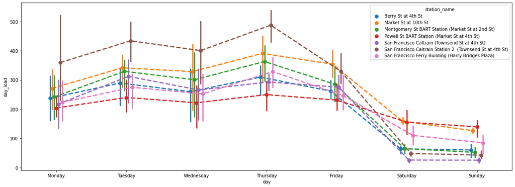

```python
plt.figure(figsize=(20,7))
sns.pointplot(data = stations_usage[stations_usage.station_name.isin(top_usage)],x = 'day',y='day_load',hue = 'station_name',dodge = True,order = order,linestyles = '--');
```

Significant information for business decisions here, on average there 250-350 usage of this station on weekdays, 50-150 on weekends.

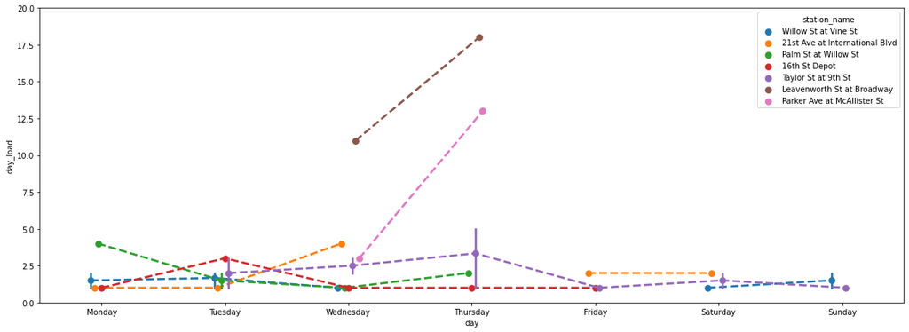

```python
plt.figure(figsize=(20,7))
sns.pointplot(data = stations_usage[stations_usage.station_name.isin(low_usage)],x = 'day',y='day_load',hue = 'station_name',order = order,dodge = True,linestyles = '--');
plt.ylim(0,20);
```

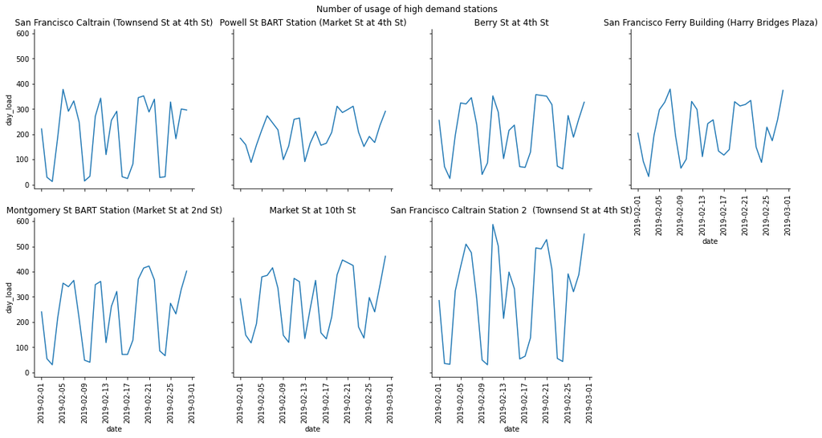

```python
g = sns.FacetGrid(data= stations_usage[stations_usage.station_name.isin(top_usage)],col= 'station_name', height = 4, col_wrap=4, margin_titles=True,col_order=top_usage);
g.map(plt.plot, 'date' , 'day_load');
g.set_xticklabels(rotation = 90);
axes = g.axes.flatten()
for x in range(len(top_usage)):
    axes[x].set_title(top_usage[x])
g.fig.subplots_adjust(top = 0.92);
g.fig.suptitle('Number of usage of high demand stations');
```

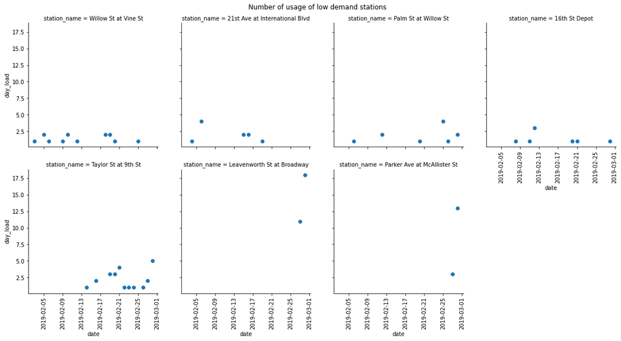

```python
g = sns.FacetGrid(data= stations_usage[stations_usage.station_name.isin(low_usage)],col= 'station_name', height = 4, col_wrap=4, margin_titles=True);
g.map(plt.scatter, 'date' , 'day_load');
g.set_xticklabels(rotation = 90);
axes = g.axes.flatten()
#for x in range(len(low_usage)):
#    axes[x].set_title(low_usage[x])
g.fig.subplots_adjust(top = 0.92);
g.fig.suptitle('Number of usage of low demand stations');
```

Let's look how stations will look like on the map with information about day load

```python
stations_usage = pd.merge(stations_usage, df[['start_station_name','start_station_longitude','start_station_latitude']].drop_duplicates(),how='left',left_on=['station_name'],right_on=['start_station_name'])
stations_usage.rename(columns={'start_station_latitude':'station_latitude','start_station_longitude':'station_longitude'},inplace=True)
stations_usage.drop(columns=['start_station_name'],inplace=True)
```

```python
stations_usage.head()
```

|  | date | station_name | number_of_starts | number_of_finishes | day | day_load | station_longitude | station_latitude |
| --- | --- | --- | --- | --- | --- | --- | --- | --- |
| 0 | 2019-02-01 | 10th Ave at E 15th St | 2 | 0 | Friday | 2 | -122.248780 | 37.792714 |
| 1 | 2019-02-01 | 10th St at Fallon St | 10 | 15 | Friday | 25 | -122.262997 | 37.797673 |
| 2 | 2019-02-01 | 10th St at University Ave | 8 | 6 | Friday | 14 | -122.293400 | 37.869060 |
| 3 | 2019-02-01 | 11th St at Bryant St | 22 | 35 | Friday | 57 | -122.411726 | 37.770030 |
| 4 | 2019-02-01 | 11th St at Natoma St | 28 | 31 | Friday | 59 | -122.416040 | 37.773507 |

```python
stations_load = stations_usage.groupby(['station_name','station_longitude','station_latitude'])['day_load'].sum().reset_index()
stations_load.rename(columns = {'day_load':'month_load'},inplace = True)
stations_load['avg_day_load'] = stations_load.month_load/stations_usage.date.nunique()
stations_load.head(1)
```

|  | station_name | station_longitude | station_latitude | month_load | avg_day_load |
| --- | --- | --- | --- | --- | --- |
| 0 | 10th Ave at E 15th St | -122.24878 | 37.792714 | 94 | 3.357143 |

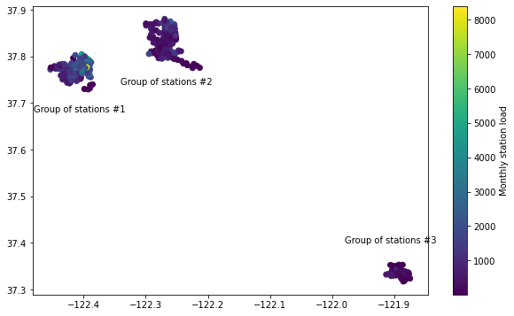

```python
plt.figure(figsize=(10,6))
plt.scatter(data = stations_load,x = 'station_longitude', y = 'station_latitude',c='month_load');
plt.colorbar(label = 'Monthly station load');
plt.text(-122.48,37.68,'Group of stations #1');
plt.text(-122.34,37.74,'Group of stations #2');
plt.text(-121.98,37.4,'Group of stations #3');
```

So there are 3 groups of stations, let's plot them independently and add information about their daily load.

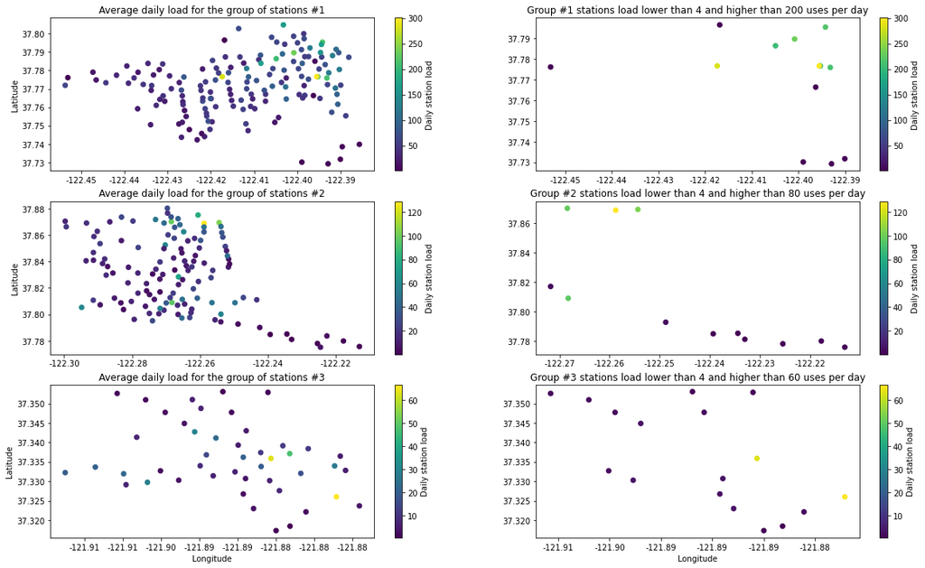

```python
from matplotlib.ticker import StrMethodFormatter
plt.figure(figsize=(20,12))

plt.subplot(3,2,1)
plt.scatter(data = stations_load[stations_load.station_longitude<-122.3],x = 'station_longitude', y = 'station_latitude', c = 'avg_day_load',cmap= 'viridis');
plt.colorbar(label = 'Daily station load');
plt.title('Average daily load for the group of stations #1');
plt.ylabel('Latitude');
plt.gca().xaxis.set_major_formatter(StrMethodFormatter('{x:,.2f}'));

plt.subplot(3,2,2)
plt.scatter(data = stations_load[(stations_load.station_longitude<-122.3)&((stations_load.avg_day_load<4)|(stations_load.avg_day_load>200))],x = 'station_longitude', y = 'station_latitude', c = 'avg_day_load',cmap= 'viridis');
plt.colorbar(label = 'Daily station load');
plt.title('Group #1 stations load lower than 4 and higher than 200 uses per day');
plt.gca().xaxis.set_major_formatter(StrMethodFormatter('{x:,.2f}'));

plt.subplot(3,2,3)
plt.scatter(data = stations_load[(stations_load.station_longitude>-122.35) & (stations_load.station_longitude<-122.0)],x = 'station_longitude', y = 'station_latitude', c = 'avg_day_load',cmap= 'viridis');
plt.colorbar(label = 'Daily station load');
plt.title('Average daily load for the group of stations #2');
plt.ylabel('Latitude');
plt.gca().xaxis.set_major_formatter(StrMethodFormatter('{x:,.2f}'));

plt.subplot(3,2,4)
plt.scatter(data = stations_load[((stations_load.station_longitude>-122.35) & (stations_load.station_longitude<-122.0))&((stations_load.avg_day_load<4)|(stations_load.avg_day_load>80))],x = 'station_longitude', y = 'station_latitude', c = 'avg_day_load',cmap= 'viridis');
plt.colorbar(label = 'Daily station load');
plt.title('Group #2 stations load lower than 4 and higher than 80 uses per day');
plt.gca().xaxis.set_major_formatter(StrMethodFormatter('{x:,.2f}'));

plt.subplot(3,2,5)
plt.scatter(data = stations_load[stations_load.station_longitude>-122],x = 'station_longitude', y = 'station_latitude', c = 'avg_day_load',cmap= 'viridis');
plt.colorbar(label = 'Daily station load');
plt.title('Average daily load for the group of stations #3');
plt.xlabel('Longitude');
plt.ylabel('Latitude');
plt.gca().xaxis.set_major_formatter(StrMethodFormatter('{x:,.2f}'));

plt.subplot(3,2,6)
plt.scatter(data = stations_load[(stations_load.station_longitude>-122)&((stations_load.avg_day_load<4)|(stations_load.avg_day_load>60))],x = 'station_longitude', y = 'station_latitude', c = 'avg_day_load',cmap= 'viridis');
plt.colorbar(label = 'Daily station load');
plt.title('Group #3 stations load lower than 4 and higher than 60 uses per day');
plt.xlabel('Longitude');
plt.gca().xaxis.set_major_formatter(StrMethodFormatter('{x:,.2f}'));
```

## Conclusions

I start exploration with posing next questions:

1. When are most trips taken in terms day of the week, number of week or month of the year?
2. How long does the average trip take?
3. Does the above depend on if a user is a subscriber or customer?

All questions have clear answers in the work above. Also, while I was working with the dataset, I found that there are a few more questions to add, such as which stations are the busiest and which stations are not. The answer to this question can help a business understand where to move excess equipment and from which station it can be collected, as well as help to better move people's resources between stations.